# Analyze the Popularity of Programming Languages

# Description

Project prompt:

> How can you determine which programming languages and technologies are most widely used? Which languages are gaining or losing popularity, helping you decide where to focus your efforts?

> One excellent data source is Stack Overflow, a programming question-and-answer site with more than 16 million questions on programming topics. Each Stack Overflow question is tagged with a label identifying its topic or technology. By counting the number of questions related to each technology, you can estimate the popularity of different programming languages.

> In this project, you will use data from the [Stack Exchange Data Explorer](https://data.stackexchange.com/) to examine the relative popularity of R compared to other programming languages.

> You’ll work with a dataset containing one observation per tag per year, including the number of questions for that tag and the total number of questions that year.

`stack_overflow_data.csv`

| Column | Description |
| --- | --- |
| `year` | The year the question was asked (2008-2020) |
| `tag` | A word or phrase that describes the topic of the question, such as the programming language |
| `num_questions` | The number of questions with a certain tag in that year |
| `year_total` | The total number of questions asked in that year |

# Assumptions

Assumptions about dataset:

- All questions about R are tagged with “r”.
- Each combination of year and tag occurs no more than once. (i.e. tags are never duplicated within the same year)

# Setup

```r
# Load necessary packages
library(readr)
library(dplyr)
library(ggplot2)
library(stringr)
```

```r
# Load the dataset
data <- read_csv("stack_overflow_data.csv")
```

```r
# View the dataset
head(data)
```

| year | tag | num_questions | year_total |
| --- | --- | --- | --- |
| 2008 | treeview | 69 | 168541 |
| 2008 | scheduled-tasks | 30 | 168541 |
| 2008 | specifications | 21 | 168541 |
| 2008 | rendering | 35 | 168541 |
| 2008 | http-post | 6 | 168541 |
| 2008 | static-assert | 1 | 168541 |

# Analysis

## R-related questions

Question 1:

> What was the percentage of R questions in 2020? Save the result in a data frame, r_2020, containing five columns: year, tag, num_questions, year_total, and percentage.

```r
r_2020 <- data %>%
    filter(year == 2020, tag == "r") %>%
    mutate(percentage = num_questions / year_total * 100)

r_2020
```

| year | tag | num_questions | year_total | percentage |
| --- | --- | --- | --- | --- |
| 2020 | r | 52662 | 5452545 | 0.9658242 |

## Most-asked-about programming languages

Question 2:

> Identify the five programming language tags with the highest total number of questions asked between 2015 and 2020 (inclusive). Save the tag names as “highest_tags”. This variable can be a character vector, tibble, or data frame (if the latter, please use the column name “tag”).

```r
highest_tags <- data %>%
    # Filter for language tags with questions asked between 2015 and 2020
    filter(year >= 2015 & year <= 2020) %>%
    # For each programming language tag, calculate total number of questions asked
    group_by(tag) %>%
    summarise(total_num_questions = sum(num_questions)) %>%
    ungroup() %>%
    # Then get the five language tags with highest number of questions asked
    slice_max(total_num_questions, n=5) %>%
    arrange(desc(total_num_questions))

highest_tags
```

| tag | total_num_questions |
| --- | --- |
| javascript | 1373634 |
| python | 1187838 |
| java | 982747 |
| android | 737330 |
| c# | 730045 |

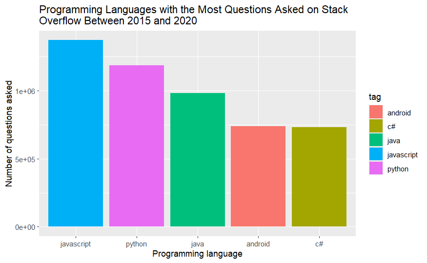

```r
# Visualise this data
ggplot(highest_tags, aes(x = reorder(tag, -total_num_questions), y = total_num_questions, fill = tag)) +
    geom_col() +
    labs(x = "Programming language",
         y = "Number of questions asked",
         title = str_wrap("Programming Languages with the Most Questions Asked on Stack Overflow Between 2015
                          and 2020", 60),
         alt = "A bar plot showing the number of questions asked about five programming languages")
```

# Final thoughts and further questions

I would like to look further into the context in which these languages have become popular– some questions might include:

- What popular technologies were introduced between 2008-2020 that are related to the five programming language tags with the most questions?
  - For example, React was released in 2013 and is maintained and used by Facebook– how did this affect the number of JavaScript-related questions?
  - Or, did the number of Python questions at the same time as, or shortly after, the release of ChatGPT in 2022?)